# Lung Cap Data Analysis_Priti_Das

ANOVA MODEL

```python
anova_model1_model2=anova_lm(model1, model2)
```

```python
anova_model2_model3=anova_lm(model2, model3)
```

```python
print("ANOVA between model 1 and model 2:")
print(anova_model1_model2)
```

```
ANOVA between model 1 and model 2:
   df_resid          ssr  df_diff    ss_diff          F        Pr(>F)
0     652.0  1088.405828      0.0        NaN        NaN           NaN
1     651.0   998.092326      1.0  90.313502  58.906464  6.068515e-14
```

The model 2 has alower sum of squared residuals of 998.09 compared to the model 1 which is 1088.41, which suggests that it accounts for more variance in Lung Capacity. The considerable difference of 90.31 highlights the positive impact of adding quadratic term in improving model performance. The high F-statistics of 58.91 and the extremely low low p-value demonstrates a better fit than the linear model. The small p-value confirms that this improvement is unlikely to be a result of being coincidental.

```python
print("ANOVA between model 2 and model 3:")
print(anova_model2_model3)
```

```
ANOVA between model 2 and model 3:
   df_resid         ssr  df_diff   ss_diff        F    Pr(>F)
0     651.0  998.092326      0.0       NaN      NaN       NaN
1     650.0  997.791669      1.0  0.300658  0.19586  0.658231
```

```python
height_range=np.linspace(data['Height'].min(), data['Height'].max(), 100)
```

```python
predictions_model1=model1.predict(pd.DataFrame({'Height': height_range}))
predictions_model2=model2.predict(pd.DataFrame({'Height': height_range, 'Height_squared': height_range**2}))
predictions_model3=model3.predict(pd.DataFrame({'Height': height_range, 'Height_squared': height_range**2, 'Height_cubed': height_range**3}))
```

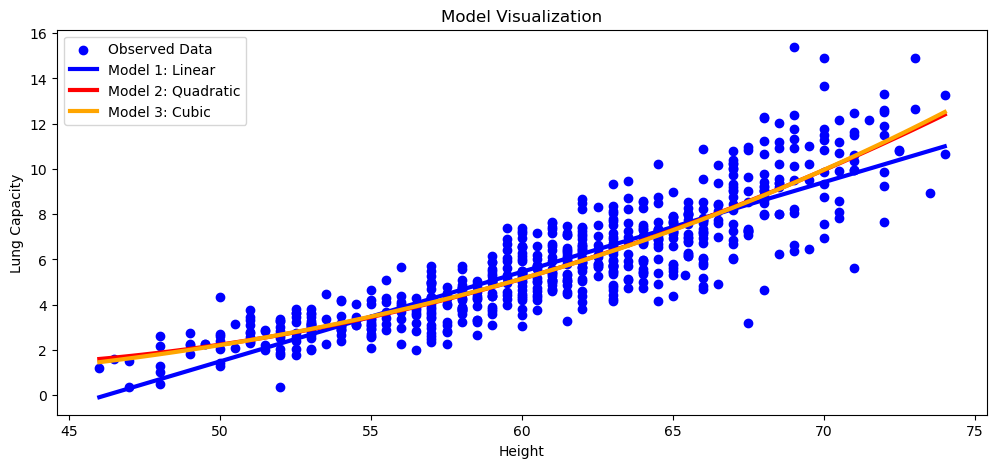

```python
plt.figure(figsize=(12,5))
plt.scatter(data['Height'], data['LungCap'], label='Observed Data', color='blue')
plt.plot(height_range, predictions_model1, label='Model 1: Linear', color='blue', linewidth=3)
plt.plot(height_range, predictions_model2, label='Model 2: Quadratic', color='red', linewidth=3)
plt.plot(height_range, predictions_model3, label='Model 3: Cubic', color='orange', linewidth=3)
plt.title('Model Visualization')
plt.xlabel('Height')
plt.ylabel('Lung Capacity')
plt.legend()
plt.show()
```

References: "How to perform a One-Way Anova in Python".4,July,2022 https://www.geeksforgeeks.org/how-to-perform-a-one-way-anova-in-python/

"Python for Data 26:ANOVA".Greg Hamel.Kaggle https://www.kaggle.com/code/hamelg/python-for-data-26-anova